# R Notebook

# Broadband policy 2021

This is all of the backend code for this paper.

### Some data prep

Let’s begin at basics. According to the [most recent survey data](https://www.pewresearch.org/fact-tank/2019/04/22/some-americans-dont-use-the-internet-who-are-they/) from Pew, about 10 percent of Americans aren’t connected to the Internet. [As Pew noted](https://www.pewresearch.org/fact-tank/2019/04/22/some-americans-dont-use-the-internet-who-are-they/), “The size of this group has changed little over the past four years, despite ongoing government and social service programs to encourage internet adoption in underserved areas.”

I pulled NTIA’s Internet Use Survey data to do some analysis. The excel file is included.

```r
setwd("~/Documents/GitHub/broadband/broadband/docs")
NTIAraw <- read_excel("ntia-internet-use.xlsx", sheet = 1)
NTIAraw <- as.data.frame(NTIAraw)
NTIAraw$dataset <- as.Date(NTIAraw$dataset)
```

First, let’s take a look at the variables.

```r
names(NTIAraw)
```

```
  [1] "dataset"               "variable"              "description"           "universe"              "usProp"
  [6] "usPropSE"              "usCount"               "usCountSE"             "age314Prop"            "age314PropSE"
 [11] "age314Count"           "age314CountSE"         "age1524Prop"           "age1524PropSE"         "age1524Count"
 [16] "age1524CountSE"        "age2544Prop"           "age2544PropSE"         "age2544Count"          "age2544CountSE"
 [21] "age4564Prop"           "age4564PropSE"         "age4564Count"          "age4564CountSE"        "age65pProp"
 [26] "age65pPropSE"          "age65pCount"           "age65pCountSE"         "workEmployedProp"      "workEmployedPropSE"
 [31] "workEmployedCount"     "workEmployedCountSE"   "workUnemployedProp"    "workUnemployedPropSE"  "workUnemployedCount"
 [36] "workUnemployedCountSE" "workNILFProp"          "workNILFPropSE"        "workNILFCount"         "workNILFCountSE"
 [41] "incomeU25Prop"         "incomeU25PropSE"       "incomeU25Count"        "incomeU25CountSE"      "income2549Prop"
 [46] "income2549PropSE"      "income2549Count"       "income2549CountSE"     "income5074Prop"        "income5074PropSE"
 [51] "income5074Count"       "income5074CountSE"     "income7599Prop"        "income7599PropSE"      "income7599Count"
 [56] "income7599CountSE"     "income100pProp"        "income100pPropSE"      "income100pCount"       "income100pCountSE"
 [61] "edNoDiplomaProp"       "edNoDiplomaPropSE"     "edNoDiplomaCount"      "edNoDiplomaCountSE"    "edHSGradProp"
 [66] "edHSGradPropSE"        "edHSGradCount"         "edHSGradCountSE"       "edSomeCollegeProp"     "edSomeCollegePropSE"
 [71] "edSomeCollegeCount"    "edSomeCollegeCountSE"  "edCollegeGradProp"     "edCollegeGradPropSE"   "edCollegeGradCount"
```

[output cut: 55 more lines]

I know there are two groups worth understanding, the connected and the unconnected. Let’s filter the data to two groups to compare their means.

```r
unconnected_connected <- filter(NTIAraw, variable == "noInternetAtHome" | variable == "internetAtHome" |
                                  variable == "isHouseholder", dataset == "2019-11-01") %>%
  subset(., select = -dataset)
```

We need to prep the data for some basic analysis, which means we need a list of variables to compare. We can then run a function over each one of them for a table. Let’s collect all the variables we want to compare and also take out the standard errors. Thankfully, there are no errant R variables that include the capitalized SE, so let’s use match case filtering here.

```r
compare_variables <- as.data.frame(names(unconnected_connected)) %>%
  rename(demos = 'names(unconnected_connected)') %>%
  filter(!str_detect(demos, "SE")) %>%
  filter(!demos == c("dataset", "variable", "description", "universe"))
```

I like reading rows of tables, so let’s reshape the data into the long format.

```r
unconnected_connected_long <- unconnected_connected %>%
  rename(., connect = variable) %>%
  subset(., select = -c(description, universe)) %>%
  gather(., variable, value, usProp:WYCountSE, factor_key=TRUE) %>%
  spread(., connect, value) %>%
  semi_join(., compare_variables, c("variable" = "demos"))

unconnected_connected_long
```

| variable | internetAtHome | isHouseholder | noInternetAtHome |
| --- | --- | --- | --- |
| usProp | 0.798777 | 1 | 0.201223 |
| usCount | 104069680.000000 | 130286349 | 26216669.000000 |
| age314Prop | NA | NA | NA |
| age314Count | NA | NA | NA |
| age1524Prop | 0.842545 | 1 | 0.157455 |
| age1524Count | 5172456.000000 | 6139084 | 966628.000000 |
| age2544Prop | 0.865837 | 1 | 0.134163 |
| age2544Count | 37260547.000000 | 43034143 | 5773596.000000 |
| age4564Prop | 0.812860 | 1 | 0.187140 |
| age4564Count | 37868997.000000 | 46587332 | 8718335.000000 |

[output cut: 162 more lines]

### Who are the unconnected?

A couple of important stats right up top. There are 26216669 households without Internet at home. In contrast, there are 104069680 households with Internet at home for a total of 130286349 households.

[output not shown]

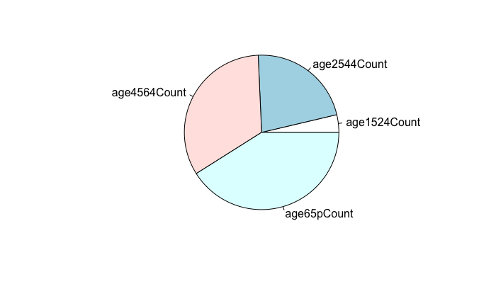

```r
pie(unconnected_connected_long_age$noInternetAtHome, unconnected_connected_long_age$variable)
```

Now let’s look at income.

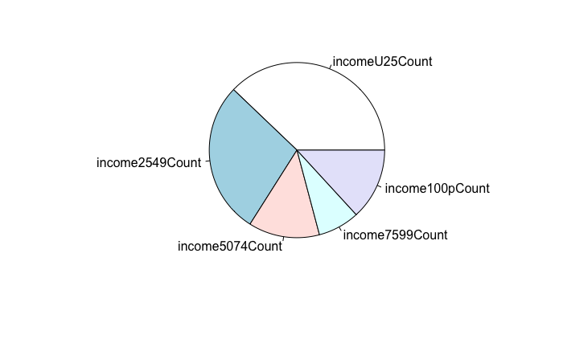

```r
unconnected_connected_long_income <- unconnected_connected_long %>%
  filter(str_detect(variable, "income")) %>%
  filter(str_detect(variable, "Count")) %>%
  na.omit(.)

pie(unconnected_connected_long_income$noInternetAtHome, unconnected_connected_long_income$variable)
```

Now let’s look at educational attainment.

```r
unconnected_connected_long_ed <- unconnected_connected_long %>%
  filter(str_starts(variable, "ed")) %>%
  filter(str_detect(variable, "Count")) %>%
  na.omit(.)

unconnected_connected_long_ed
```

|  | variable | internetAtHome | isHouseholder | noInternetAtHome |
| --- | --- | --- | --- | --- |
| 1 | edNoDiplomaCount | 6706214 | 11564947 | 4858733 |
| 2 | edHSGradCount | 24426083 | 34161448 | 9735365 |
| 3 | edSomeCollegeCount | 30816421 | 36935096 | 6118675 |
| 4 | edCollegeGradCount | 42120963 | 47624858 | 5503895 |

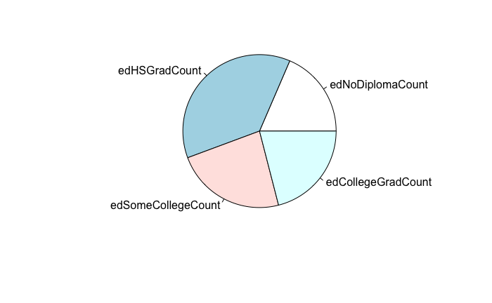

```r
pie(unconnected_connected_long_ed$noInternetAtHome, unconnected_connected_long_ed$variable)
```

Next, let’s look at race.

```r
unconnected_connected_long_race <- unconnected_connected_long %>%
  filter(str_starts(variable, "race")) %>%
  filter(str_detect(variable, "Count")) %>%
  na.omit(.)

unconnected_connected_long_race
```

|  | variable | internetAtHome | isHouseholder | noInternetAtHome |
| --- | --- | --- | --- | --- |
| 1 | raceWhiteCount | 69731588 | 85457641 | 15726053 |
| 2 | raceBlackCount | 12267047 | 16726336 | 4459288 |
| 3 | raceHispanicCount | 14065872 | 18313079 | 4247207 |
| 4 | raceAsianCount | 5632390 | 6785165 | 1152775 |
| 5 | raceAmIndianCount | 722989 | 985272 | 262284 |
| 6 | raceOtherCount | 1649794 | 2018856 | 369062 |

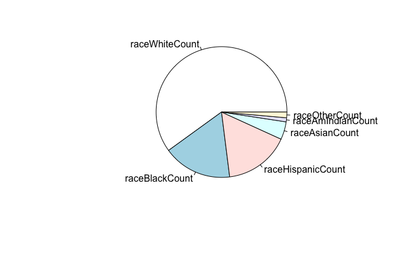

```r
pie(unconnected_connected_long_race$noInternetAtHome, unconnected_connected_long_race$variable)
```

Again, there are 26216669 households without Internet at home. In contrast, there are 104069680 households with Internet at home for a total of 130286349 households. Let’s compare percentages to see which demographics skew the profile. In other words, given what we know about the United States, which factors deviate from the norm?

```r
unconnected_connected_long_demos <- unconnected_connected_long[1:70, ] %>%
  filter(str_detect(variable, "Count")) %>%
  na.omit(.) %>%
  mutate(., isHouseholder_per = ((isHouseholder)/130286349) * 100) %>%
  mutate(., noInternetAtHome_per = ((noInternetAtHome)/26216669) * 100) %>%
  mutate(., percentdifference = ((noInternetAtHome_per - isHouseholder_per)/isHouseholder_per) * 100)

formattable(unconnected_connected_long_demos)
```

|  | variable | internetAtHome | isHouseholder | noInternetAtHome | isHouseholder_per | noInternetAtHome_per | percentdifference |
| --- | --- | --- | --- | --- | --- | --- | --- |
| 1 | usCount | 104069680 | 130286349 | 26216669 | 100.0000000 | 100.000000 | 0.0000000 |
| 3 | age1524Count | 5172456 | 6139084 | 966628 | 4.7119933 | 3.687074 | -21.7512879 |
| 4 | age2544Count | 37260547 | 43034143 | 5773596 | 33.0304313 | 22.022615 | -33.3262878 |
| 5 | age4564Count | 37868997 | 46587332 | 8718335 | 35.7576464 | 33.254930 | -6.9991075 |
| 6 | age65pCount | 23767680 | 34525791 | 10758111 | 26.4999298 | 41.035385 | 54.8509189 |
| 7 | workEmployedCount | 68959792 | 80738061 | 11778269 | 61.9697011 | 44.926642 | -27.5022452 |
| 8 | workUnemployedCount | 1928667 | 2352695 | 424028 | 1.8057878 | 1.617398 | -10.4325295 |
| 9 | workNILFCount | 32782154 | 46751687 | 13969533 | 35.8837955 | 53.284927 | 48.4930079 |
| 10 | incomeU25Count | 15677265 | 25603010 | 9925746 | 19.6513374 | 37.860439 | 92.6608778 |
| 11 | income2549Count | 24062223 | 31443440 | 7381217 | 24.1341017 | 28.154671 | 16.6592885 |
| 12 | income5074Count | 20066170 | 23506405 | 3440235 | 18.0421089 | 13.122319 | -27.2683737 |
| 13 | income7599Count | 13784675 | 15798061 | 2013386 | 12.1256456 | 7.679793 | -36.6648707 |
| 14 | income100pCount | 30479347 | 33935433 | 3456085 | 26.0468063 | 13.182777 | -49.3881254 |
| 15 | edNoDiplomaCount | 6706214 | 11564947 | 4858733 | 8.8765608 | 18.532991 | 108.7857195 |
| 16 | edHSGradCount | 24426083 | 34161448 | 9735365 | 26.2202819 | 37.134256 | 41.6241679 |
| 17 | edSomeCollegeCount | 30816421 | 36935096 | 6118675 | 28.3491680 | 23.338873 | -17.6735181 |
| 18 | edCollegeGradCount | 42120963 | 47624858 | 5503895 | 36.5539892 | 20.993876 | -42.5674830 |
| 19 | sexMaleCount | 52544979 | 65017426 | 12472447 | 49.9034830 | 47.574492 | -4.6669916 |
| 20 | sexFemaleCount | 51524701 | 65268923 | 13744222 | 50.0965170 | 52.425508 | 4.6490085 |
| 21 | raceWhiteCount | 69731588 | 85457641 | 15726053 | 65.5921681 | 59.984939 | -8.5486254 |
| 22 | raceBlackCount | 12267047 | 16726336 | 4459288 | 12.8381339 | 17.009361 | 32.4909177 |
| 23 | raceHispanicCount | 14065872 | 18313079 | 4247207 | 14.0560229 | 16.200407 | 15.2559786 |
| 24 | raceAsianCount | 5632390 | 6785165 | 1152775 | 5.2078864 | 4.397107 | -15.5682989 |
| 25 | raceAmIndianCount | 722989 | 985272 | 262284 | 0.7562358 | 1.000447 | 32.2930596 |
| 26 | raceOtherCount | 1649794 | 2018856 | 369062 | 1.5495530 | 1.407738 | -9.1519957 |
| 27 | disabilityNoCount | 91790936 | 111163842 | 19372907 | 85.3227087 | 73.895379 | -13.3930691 |
| 28 | disabilityYesCount | 11879678 | 18678601 | 6798923 | 14.3365757 | 25.933588 | 80.8910921 |
| 29 | metroNoCount | 12865555 | 17494866 | 4629311 | 13.4280116 | 17.657892 | 31.5004202 |
| 30 | metroYesCount | 90379389 | 111753288 | 21373899 | 85.7751321 | 81.527897 | -4.9515922 |
| 31 | metroUnknownCount | 824736 | 1038195 | 213459 | 0.7968563 | 0.814211 | 2.1778925 |
| 32 | scChldHomeNoCount | 78224325 | 100812385 | 22588060 | 77.3775501 | 86.159153 | 11.3490322 |
| 33 | scChldHomeYesCount | 25845355 | 29473964 | 3628609 | 22.6224499 | 13.840847 | -38.8180904 |
| 34 | veteranNoCount | 94415211 | 118081191 | 23665980 | 90.6320516 | 90.270736 | -0.3986623 |
| 35 | veteranYesCount | 9196730 | 11690845 | 2494116 | 8.9731926 | 9.513474 | 6.0210617 |

Finally, let’s take a look at the states

```r
unconnected_connected_long_state <- unconnected_connected_long[71:172, ] %>%
  filter(str_detect(variable, "Count")) %>%
  na.omit(.)

formattable(unconnected_connected_long_state)
```

| variable | internetAtHome | isHouseholder | noInternetAtHome |
| --- | --- | --- | --- |
| ALCount | 1654253 | 2057823 | 403570 |
| AKCount | 217723 | 267631 | 49908 |
| AZCount | 2347790 | 2810542 | 462752 |
| ARCount | 1021040 | 1275479 | 254438 |
| CACount | 11378020 | 14235012 | 2856992 |
| COCount | 2078052 | 2366826 | 288774 |
| CTCount | 1142445 | 1449059 | 306614 |
| DECount | 307748 | 387842 | 80094 |
| DCCount | 293100 | 343485 | 50385 |
| FLCount | 7172671 | 9176306 | 2003635 |
| GACount | 3318541 | 4237325 | 918784 |
| HICount | 431593 | 496373 | 64780 |
| IDCount | 585159 | 696205 | 111046 |
| ILCount | 4193312 | 5000939 | 807627 |
| INCount | 2164673 | 2683353 | 518680 |
| IACount | 1071727 | 1311190 | 239463 |
| KSCount | 936010 | 1158139 | 222129 |
| KYCount | 1460989 | 1918049 | 457059 |
| LACount | 1433929 | 1894451 | 460523 |
| MECount | 471867 | 589618 | 117751 |
| MDCount | 1967264 | 2291594 | 324330 |
| MACount | 2293912 | 2888407 | 594496 |
| MICount | 3338786 | 4144812 | 806026 |
| MNCount | 1952164 | 2249647 | 297483 |
| MSCount | 894324 | 1184106 | 289782 |
| MOCount | 1936168 | 2415518 | 479350 |
| MTCount | 364997 | 454933 | 89936 |
| NECount | 649097 | 811139 | 162042 |
| NVCount | 992671 | 1234656 | 241985 |
| NHCount | 485085 | 557845 | 72760 |
| NJCount | 2735578 | 3406177 | 670600 |
| NMCount | 682725 | 859635 | 176910 |
| NYCount | 6020899 | 7845407 | 1824508 |
| NCCount | 3212782 | 4336469 | 1123687 |
| NDCount | 256269 | 322167 | 65898 |
| OHCount | 3782398 | 4844692 | 1062294 |
| OKCount | 1293391 | 1602134 | 308743 |
| ORCount | 1492605 | 1732476 | 239872 |
| PACount | 3820182 | 5004797 | 1184615 |
| RICount | 337530 | 411319 | 73789 |
| SCCount | 1812815 | 2214685 | 401871 |
| SDCount | 293903 | 367110 | 73206 |
| TNCount | 2071353 | 2732458 | 661105 |
| TXCount | 8524311 | 10750119 | 2225809 |
| UTCount | 953391 | 1088083 | 134692 |
| VTCount | 223223 | 276999 | 53776 |
| VACount | 2868490 | 3456537 | 588047 |
| WACount | 2471797 | 3058661 | 586864 |
| WVCount | 563190 | 743497 | 180307 |
| WICount | 1916237 | 2406328 | 490091 |
| WYCount | 181498 | 238290 | 56792 |